# Risk Factor Analysis

## Outcome Variable

**Outcome Variable:** wasted

## Predictor Variables

**Intervention Variable:** enstunt

**Adjustment Set:**

unadjusted

## Stratifying Variables

The analysis was stratified on these variable(s):

- agecat
- studyid
- country

## Data Summary

| agecat | studyid | country | enstunt | wasted | n_cell | n |
| --- | --- | --- | --- | --- | --- | --- |
| Birth | CMC-V-BCS-2002 | INDIA | 0 | 0 | 66 | 86 |
| Birth | CMC-V-BCS-2002 | INDIA | 0 | 1 | 8 | 86 |
| Birth | CMC-V-BCS-2002 | INDIA | 1 | 0 | 9 | 86 |
| Birth | CMC-V-BCS-2002 | INDIA | 1 | 1 | 3 | 86 |
| Birth | CMIN | BANGLADESH | 0 | 0 | 14 | 19 |
| Birth | CMIN | BANGLADESH | 0 | 1 | 3 | 19 |
| Birth | CMIN | BANGLADESH | 1 | 0 | 1 | 19 |
| Birth | CMIN | BANGLADESH | 1 | 1 | 1 | 19 |
| Birth | COHORTS | GUATEMALA | 0 | 0 | 540 | 756 |
| Birth | COHORTS | GUATEMALA | 0 | 1 | 192 | 756 |
| Birth | COHORTS | GUATEMALA | 1 | 0 | 24 | 756 |
| Birth | COHORTS | GUATEMALA | 1 | 1 | 0 | 756 |
| Birth | COHORTS | INDIA | 0 | 0 | 4772 | 6193 |
| Birth | COHORTS | INDIA | 0 | 1 | 1041 | 6193 |
| Birth | COHORTS | INDIA | 1 | 0 | 325 | 6193 |
| Birth | COHORTS | INDIA | 1 | 1 | 55 | 6193 |
| Birth | COHORTS | PHILIPPINES | 0 | 0 | 2373 | 2899 |
| Birth | COHORTS | PHILIPPINES | 0 | 1 | 440 | 2899 |
| Birth | COHORTS | PHILIPPINES | 1 | 0 | 75 | 2899 |
| Birth | COHORTS | PHILIPPINES | 1 | 1 | 11 | 2899 |
| Birth | CONTENT | PERU | 0 | 0 | 2 | 2 |
| Birth | CONTENT | PERU | 0 | 1 | 0 | 2 |
| Birth | CONTENT | PERU | 1 | 0 | 0 | 2 |
| Birth | CONTENT | PERU | 1 | 1 | 0 | 2 |
| Birth | EE | PAKISTAN | 0 | 0 | 120 | 177 |
| Birth | EE | PAKISTAN | 0 | 1 | 17 | 177 |
| Birth | EE | PAKISTAN | 1 | 0 | 35 | 177 |
| Birth | EE | PAKISTAN | 1 | 1 | 5 | 177 |
| Birth | GMS-Nepal | NEPAL | 0 | 0 | 450 | 641 |
| Birth | GMS-Nepal | NEPAL | 0 | 1 | 120 | 641 |

[output cut: 274 more lines]

The following strata were considered:

- agecat: 24 months, studyid: CMC-V-BCS-2002, country: INDIA
- agecat: 24 months, studyid: CMIN, country: BANGLADESH
- agecat: 24 months, studyid: COHORTS, country: GUATEMALA
- agecat: 24 months, studyid: COHORTS, country: INDIA
- agecat: 24 months, studyid: COHORTS, country: PHILIPPINES
- agecat: 24 months, studyid: CONTENT, country: PERU
- agecat: 24 months, studyid: EE, country: PAKISTAN
- agecat: 24 months, studyid: GMS-Nepal, country: NEPAL
- agecat: 24 months, studyid: IRC, country: INDIA
- agecat: 24 months, studyid: Keneba, country: GAMBIA
- agecat: 24 months, studyid: LCNI-5, country: MALAWI
- agecat: 24 months, studyid: MAL-ED, country: BANGLADESH
- agecat: 24 months, studyid: MAL-ED, country: BRAZIL
- agecat: 24 months, studyid: MAL-ED, country: INDIA
- agecat: 24 months, studyid: MAL-ED, country: NEPAL
- agecat: 24 months, studyid: MAL-ED, country: PERU
- agecat: 24 months, studyid: MAL-ED, country: SOUTH AFRICA
- agecat: 24 months, studyid: MAL-ED, country: TANZANIA, UNITED REPUBLIC OF
- agecat: 24 months, studyid: NIH-Birth, country: BANGLADESH
- agecat: 24 months, studyid: NIH-Crypto, country: BANGLADESH
- agecat: 24 months, studyid: PROBIT, country: BELARUS
- agecat: 24 months, studyid: PROVIDE, country: BANGLADESH
- agecat: 24 months, studyid: TanzaniaChild2, country: TANZANIA, UNITED REPUBLIC OF
- agecat: 24 months, studyid: ZVITAMBO, country: ZIMBABWE
- agecat: 6 months, studyid: CMC-V-BCS-2002, country: INDIA
- agecat: 6 months, studyid: CMIN, country: BANGLADESH
- agecat: 6 months, studyid: COHORTS, country: GUATEMALA
- agecat: 6 months, studyid: COHORTS, country: INDIA
- agecat: 6 months, studyid: COHORTS, country: PHILIPPINES
- agecat: 6 months, studyid: CONTENT, country: PERU
- agecat: 6 months, studyid: EE, country: PAKISTAN
- agecat: 6 months, studyid: GMS-Nepal, country: NEPAL
- agecat: 6 months, studyid: Guatemala BSC, country: GUATEMALA
- agecat: 6 months, studyid: IRC, country: INDIA
- agecat: 6 months, studyid: Keneba, country: GAMBIA
- agecat: 6 months, studyid: LCNI-5, country: MALAWI
- agecat: 6 months, studyid: MAL-ED, country: BANGLADESH
- agecat: 6 months, studyid: MAL-ED, country: BRAZIL
- agecat: 6 months, studyid: MAL-ED, country: INDIA
- agecat: 6 months, studyid: MAL-ED, country: NEPAL
- agecat: 6 months, studyid: MAL-ED, country: PERU
- agecat: 6 months, studyid: MAL-ED, country: SOUTH AFRICA
- agecat: 6 months, studyid: MAL-ED, country: TANZANIA, UNITED REPUBLIC OF
- agecat: 6 months, studyid: NIH-Birth, country: BANGLADESH
- agecat: 6 months, studyid: NIH-Crypto, country: BANGLADESH
- agecat: 6 months, studyid: PROBIT, country: BELARUS
- agecat: 6 months, studyid: PROVIDE, country: BANGLADESH
- agecat: 6 months, studyid: ResPak, country: PAKISTAN
- agecat: 6 months, studyid: SAS-CompFeed, country: INDIA
- agecat: 6 months, studyid: SAS-FoodSuppl, country: INDIA
- agecat: 6 months, studyid: TanzaniaChild2, country: TANZANIA, UNITED REPUBLIC OF
- agecat: 6 months, studyid: ZVITAMBO, country: ZIMBABWE
- agecat: Birth, studyid: CMC-V-BCS-2002, country: INDIA
- agecat: Birth, studyid: CMIN, country: BANGLADESH
- agecat: Birth, studyid: COHORTS, country: GUATEMALA
- agecat: Birth, studyid: COHORTS, country: INDIA
- agecat: Birth, studyid: COHORTS, country: PHILIPPINES
- agecat: Birth, studyid: CONTENT, country: PERU
- agecat: Birth, studyid: EE, country: PAKISTAN
- agecat: Birth, studyid: GMS-Nepal, country: NEPAL
- agecat: Birth, studyid: IRC, country: INDIA
- agecat: Birth, studyid: Keneba, country: GAMBIA
- agecat: Birth, studyid: MAL-ED, country: BANGLADESH
- agecat: Birth, studyid: MAL-ED, country: BRAZIL
- agecat: Birth, studyid: MAL-ED, country: INDIA
- agecat: Birth, studyid: MAL-ED, country: NEPAL
- agecat: Birth, studyid: MAL-ED, country: PERU
- agecat: Birth, studyid: MAL-ED, country: SOUTH AFRICA
- agecat: Birth, studyid: MAL-ED, country: TANZANIA, UNITED REPUBLIC OF
- agecat: Birth, studyid: NIH-Birth, country: BANGLADESH
- agecat: Birth, studyid: NIH-Crypto, country: BANGLADESH
- agecat: Birth, studyid: PROBIT, country: BELARUS
- agecat: Birth, studyid: PROVIDE, country: BANGLADESH
- agecat: Birth, studyid: ResPak, country: PAKISTAN
- agecat: Birth, studyid: SAS-CompFeed, country: INDIA
- agecat: Birth, studyid: ZVITAMBO, country: ZIMBABWE

### Dropped Strata

Some strata were dropped due to rare outcomes:

- agecat: Birth, studyid: CMC-V-BCS-2002, country: INDIA
- agecat: Birth, studyid: CMIN, country: BANGLADESH
- agecat: Birth, studyid: COHORTS, country: GUATEMALA
- agecat: Birth, studyid: CONTENT, country: PERU
- agecat: Birth, studyid: IRC, country: INDIA
- agecat: Birth, studyid: Keneba, country: GAMBIA
- agecat: Birth, studyid: MAL-ED, country: BANGLADESH
- agecat: Birth, studyid: MAL-ED, country: BRAZIL
- agecat: Birth, studyid: MAL-ED, country: INDIA
- agecat: Birth, studyid: MAL-ED, country: NEPAL
- agecat: Birth, studyid: MAL-ED, country: PERU
- agecat: Birth, studyid: MAL-ED, country: SOUTH AFRICA
- agecat: Birth, studyid: MAL-ED, country: TANZANIA, UNITED REPUBLIC OF
- agecat: Birth, studyid: PROBIT, country: BELARUS
- agecat: Birth, studyid: ResPak, country: PAKISTAN
- agecat: 6 months, studyid: CONTENT, country: PERU
- agecat: 6 months, studyid: Guatemala BSC, country: GUATEMALA
- agecat: 6 months, studyid: MAL-ED, country: BANGLADESH
- agecat: 6 months, studyid: MAL-ED, country: BRAZIL
- agecat: 6 months, studyid: MAL-ED, country: INDIA
- agecat: 6 months, studyid: MAL-ED, country: NEPAL
- agecat: 6 months, studyid: MAL-ED, country: PERU
- agecat: 6 months, studyid: MAL-ED, country: SOUTH AFRICA
- agecat: 6 months, studyid: MAL-ED, country: TANZANIA, UNITED REPUBLIC OF
- agecat: 6 months, studyid: PROBIT, country: BELARUS
- agecat: 6 months, studyid: TanzaniaChild2, country: TANZANIA, UNITED REPUBLIC OF
- agecat: 24 months, studyid: CONTENT, country: PERU
- agecat: 24 months, studyid: LCNI-5, country: MALAWI
- agecat: 24 months, studyid: MAL-ED, country: BANGLADESH
- agecat: 24 months, studyid: MAL-ED, country: BRAZIL
- agecat: 24 months, studyid: MAL-ED, country: NEPAL
- agecat: 24 months, studyid: MAL-ED, country: PERU
- agecat: 24 months, studyid: MAL-ED, country: SOUTH AFRICA
- agecat: 24 months, studyid: MAL-ED, country: TANZANIA, UNITED REPUBLIC OF
- agecat: 24 months, studyid: PROBIT, country: BELARUS
- agecat: 24 months, studyid: TanzaniaChild2, country: TANZANIA, UNITED REPUBLIC OF

## Methods Detail

We’re interested in the causal parameters $E[Y_a]$ for all values of $a \in \mathcal{A}$. These parameters represent the mean outcome if, possibly contrary to fact, we intervened to set all units to have $A=a$. Under the randomization and positivity assumptions, these are identified by the statistical parameters $\psi_a=E_W[E_{Y|A,W}(Y|A=a,W)]$. In addition, we’re interested in the mean of $Y$, $E[Y]$ under no intervention (the observed mean). We will estimate these parameters by using SuperLearner to fit the relevant likelihood factors – $E_{Y|A,W}(Y|A=a,W)$ and $p(A=a|W)$, and then updating our likelihood fit using a joint TMLE.

For unadjusted analyses ($W=\{\}$), initial likelihoods were estimated using Lrnr_glm to estimate the simple $E(Y|A)$ and Lrnr_mean to estimate $p(A)$. For adjusted analyses, a small library containing Lrnr_glmnet, Lrnr_xgboost, and Lrnr_mean was used.

Having estimated these parameters, we will then use the delta method to estimate relative risks and attributable risks relative to a prespecified baseline level of $A$.

# Results Detail

## Results Plots

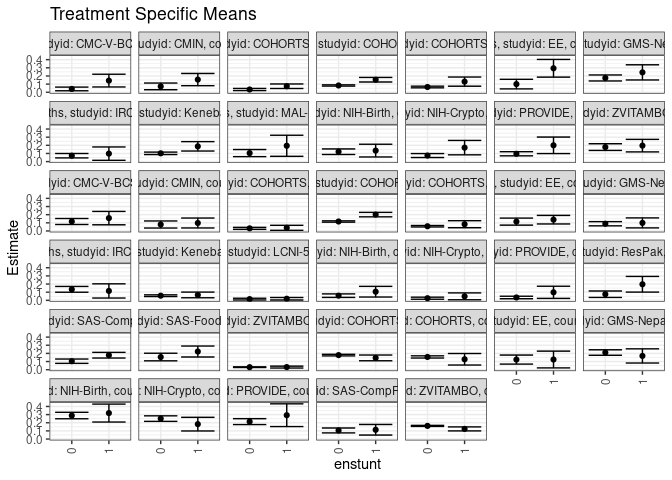

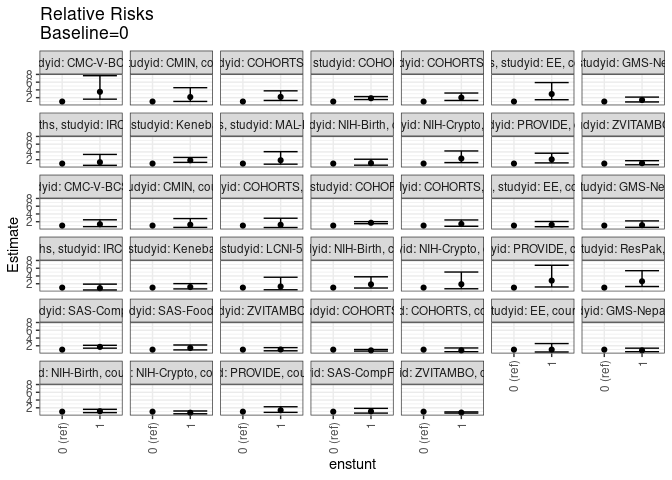

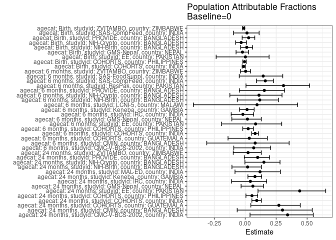

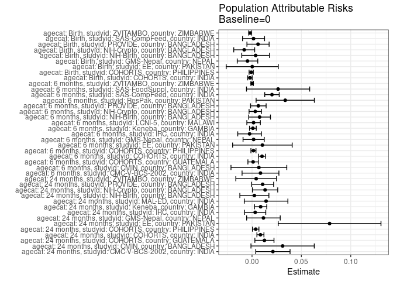

## Results Table

### Parameter: TSM

| agecat | studyid | country | intervention_level | baseline_level | estimate | ci_lower | ci_upper |
| --- | --- | --- | --- | --- | --- | --- | --- |
| Birth | COHORTS | INDIA | 0 | NA | 0.1790814 | 0.1692241 | 0.1889387 |
| Birth | COHORTS | INDIA | 1 | NA | 0.1447368 | 0.1093590 | 0.1801146 |
| Birth | COHORTS | PHILIPPINES | 0 | NA | 0.1564166 | 0.1429907 | 0.1698425 |
| Birth | COHORTS | PHILIPPINES | 1 | NA | 0.1279070 | 0.0573074 | 0.1985066 |
| Birth | EE | PAKISTAN | 0 | NA | 0.1240876 | 0.0687255 | 0.1794497 |
| Birth | EE | PAKISTAN | 1 | NA | 0.1250000 | 0.0222203 | 0.2277797 |
| Birth | GMS-Nepal | NEPAL | 0 | NA | 0.2105263 | 0.1770320 | 0.2440207 |
| Birth | GMS-Nepal | NEPAL | 1 | NA | 0.1690141 | 0.0817740 | 0.2562542 |
| Birth | NIH-Birth | BANGLADESH | 0 | NA | 0.2885375 | 0.2490256 | 0.3280495 |
| Birth | NIH-Birth | BANGLADESH | 1 | NA | 0.3188406 | 0.2087848 | 0.4288963 |
| Birth | NIH-Crypto | BANGLADESH | 0 | NA | 0.2512000 | 0.2171742 | 0.2852258 |
| Birth | NIH-Crypto | BANGLADESH | 1 | NA | 0.1829268 | 0.0991898 | 0.2666639 |
| Birth | PROVIDE | BANGLADESH | 0 | NA | 0.2138493 | 0.1775479 | 0.2501506 |
| Birth | PROVIDE | BANGLADESH | 1 | NA | 0.2926829 | 0.1532805 | 0.4320854 |
| Birth | SAS-CompFeed | INDIA | 0 | NA | 0.1054384 | 0.0753607 | 0.1355161 |
| Birth | SAS-CompFeed | INDIA | 1 | NA | 0.1138614 | 0.0488329 | 0.1788899 |
| Birth | ZVITAMBO | ZIMBABWE | 0 | NA | 0.1615278 | 0.1550044 | 0.1680511 |
| Birth | ZVITAMBO | ZIMBABWE | 1 | NA | 0.1246377 | 0.0999910 | 0.1492844 |
| 6 months | CMC-V-BCS-2002 | INDIA | 0 | NA | 0.1164384 | 0.0795988 | 0.1532779 |
| 6 months | CMC-V-BCS-2002 | INDIA | 1 | NA | 0.1578947 | 0.0758030 | 0.2399864 |
| 6 months | CMIN | BANGLADESH | 0 | NA | 0.0794702 | 0.0362411 | 0.1226993 |
| 6 months | CMIN | BANGLADESH | 1 | NA | 0.0978261 | 0.0369955 | 0.1586567 |
| 6 months | COHORTS | GUATEMALA | 0 | NA | 0.0321384 | 0.0199789 | 0.0442980 |
| 6 months | COHORTS | GUATEMALA | 1 | NA | 0.0389610 | 0.0083837 | 0.0695383 |
| 6 months | COHORTS | INDIA | 0 | NA | 0.1161750 | 0.1080893 | 0.1242607 |
| 6 months | COHORTS | INDIA | 1 | NA | 0.2009804 | 0.1734831 | 0.2284777 |
| 6 months | COHORTS | PHILIPPINES | 0 | NA | 0.0580620 | 0.0489817 | 0.0671423 |
| 6 months | COHORTS | PHILIPPINES | 1 | NA | 0.0828025 | 0.0396872 | 0.1259179 |
| 6 months | EE | PAKISTAN | 0 | NA | 0.1148325 | 0.0715513 | 0.1581138 |
| 6 months | EE | PAKISTAN | 1 | NA | 0.1385542 | 0.0859285 | 0.1911799 |
| 6 months | GMS-Nepal | NEPAL | 0 | NA | 0.0887949 | 0.0631380 | 0.1144519 |
| 6 months | GMS-Nepal | NEPAL | 1 | NA | 0.0989011 | 0.0375108 | 0.1602914 |
| 6 months | IRC | INDIA | 0 | NA | 0.1348315 | 0.0993091 | 0.1703538 |
| 6 months | IRC | INDIA | 1 | NA | 0.1153846 | 0.0284424 | 0.2023268 |
| 6 months | Keneba | GAMBIA | 0 | NA | 0.0570523 | 0.0466013 | 0.0675033 |
| 6 months | Keneba | GAMBIA | 1 | NA | 0.0663265 | 0.0314795 | 0.1011735 |
| 6 months | LCNI-5 | MALAWI | 0 | NA | 0.0150943 | 0.0047077 | 0.0254809 |
| 6 months | LCNI-5 | MALAWI | 1 | NA | 0.0194175 | 0.0040230 | 0.0348120 |
| 6 months | NIH-Birth | BANGLADESH | 0 | NA | 0.0575221 | 0.0360371 | 0.0790072 |
| 6 months | NIH-Birth | BANGLADESH | 1 | NA | 0.1058824 | 0.0404108 | 0.1713539 |
| 6 months | NIH-Crypto | BANGLADESH | 0 | NA | 0.0261011 | 0.0134710 | 0.0387313 |
| 6 months | NIH-Crypto | BANGLADESH | 1 | NA | 0.0490196 | 0.0070898 | 0.0909494 |
| 6 months | PROVIDE | BANGLADESH | 0 | NA | 0.0350554 | 0.0195587 | 0.0505520 |
| 6 months | PROVIDE | BANGLADESH | 1 | NA | 0.0983607 | 0.0235660 | 0.1731553 |
| 6 months | ResPak | PAKISTAN | 0 | NA | 0.0751445 | 0.0357785 | 0.1145105 |
| 6 months | ResPak | PAKISTAN | 1 | NA | 0.1969697 | 0.1008190 | 0.2931204 |
| 6 months | SAS-CompFeed | INDIA | 0 | NA | 0.1042312 | 0.0777378 | 0.1307245 |
| 6 months | SAS-CompFeed | INDIA | 1 | NA | 0.1780822 | 0.1433447 | 0.2128197 |
| 6 months | SAS-FoodSuppl | INDIA | 0 | NA | 0.1551724 | 0.1085207 | 0.2018241 |
| 6 months | SAS-FoodSuppl | INDIA | 1 | NA | 0.2229730 | 0.1558249 | 0.2901211 |
| 6 months | ZVITAMBO | ZIMBABWE | 0 | NA | 0.0310535 | 0.0271616 | 0.0349453 |
| 6 months | ZVITAMBO | ZIMBABWE | 1 | NA | 0.0320733 | 0.0203848 | 0.0437618 |
| 24 months | CMC-V-BCS-2002 | INDIA | 0 | NA | 0.0406780 | 0.0181053 | 0.0632507 |
| 24 months | CMC-V-BCS-2002 | INDIA | 1 | NA | 0.1428571 | 0.0645926 | 0.2211216 |
| 24 months | CMIN | BANGLADESH | 0 | NA | 0.0718954 | 0.0308800 | 0.1129108 |
| 24 months | CMIN | BANGLADESH | 1 | NA | 0.1555556 | 0.0805229 | 0.2305883 |
| 24 months | COHORTS | GUATEMALA | 0 | NA | 0.0336474 | 0.0206756 | 0.0466191 |
| 24 months | COHORTS | GUATEMALA | 1 | NA | 0.0737463 | 0.0459118 | 0.1015809 |
| 24 months | COHORTS | INDIA | 0 | NA | 0.0831543 | 0.0752207 | 0.0910878 |
| 24 months | COHORTS | INDIA | 1 | NA | 0.1538462 | 0.1258249 | 0.1818674 |
| 24 months | COHORTS | PHILIPPINES | 0 | NA | 0.0644743 | 0.0544591 | 0.0744894 |
| 24 months | COHORTS | PHILIPPINES | 1 | NA | 0.1304348 | 0.0742337 | 0.1866359 |
| 24 months | EE | PAKISTAN | 0 | NA | 0.1000000 | 0.0410253 | 0.1589747 |
| 24 months | EE | PAKISTAN | 1 | NA | 0.2941176 | 0.1854959 | 0.4027394 |
| 24 months | GMS-Nepal | NEPAL | 0 | NA | 0.1753086 | 0.1382393 | 0.2123779 |
| 24 months | GMS-Nepal | NEPAL | 1 | NA | 0.2439024 | 0.1508593 | 0.3369456 |
| 24 months | IRC | INDIA | 0 | NA | 0.0726257 | 0.0457097 | 0.0995417 |
| 24 months | IRC | INDIA | 1 | NA | 0.0980392 | 0.0163267 | 0.1797517 |
| 24 months | Keneba | GAMBIA | 0 | NA | 0.1019355 | 0.0868686 | 0.1170024 |
| 24 months | Keneba | GAMBIA | 1 | NA | 0.1875000 | 0.1298194 | 0.2451806 |
| 24 months | MAL-ED | INDIA | 0 | NA | 0.1047120 | 0.0611940 | 0.1482301 |
| 24 months | MAL-ED | INDIA | 1 | NA | 0.1944444 | 0.0648755 | 0.3240134 |
| 24 months | NIH-Birth | BANGLADESH | 0 | NA | 0.1214689 | 0.0873994 | 0.1555384 |
| 24 months | NIH-Birth | BANGLADESH | 1 | NA | 0.1351351 | 0.0571524 | 0.2131179 |
| 24 months | NIH-Crypto | BANGLADESH | 0 | NA | 0.0743243 | 0.0499027 | 0.0987459 |
| 24 months | NIH-Crypto | BANGLADESH | 1 | NA | 0.1714286 | 0.0830538 | 0.2598034 |
| 24 months | PROVIDE | BANGLADESH | 0 | NA | 0.0963391 | 0.0709327 | 0.1217456 |
| 24 months | PROVIDE | BANGLADESH | 1 | NA | 0.2000000 | 0.0987004 | 0.3012996 |
| 24 months | ZVITAMBO | ZIMBABWE | 0 | NA | 0.1782477 | 0.1369697 | 0.2195257 |
| 24 months | ZVITAMBO | ZIMBABWE | 1 | NA | 0.1960784 | 0.1189398 | 0.2732170 |

### Parameter: E(Y)

| agecat | studyid | country | intervention_level | baseline_level | estimate | ci_lower | ci_upper |
| --- | --- | --- | --- | --- | --- | --- | --- |
| Birth | COHORTS | INDIA | NA | NA | 0.1769740 | 0.1674681 | 0.1864799 |
| Birth | COHORTS | PHILIPPINES | NA | NA | 0.1555709 | 0.1423748 | 0.1687670 |
| Birth | EE | PAKISTAN | NA | NA | 0.1242938 | 0.0755526 | 0.1730349 |
| Birth | GMS-Nepal | NEPAL | NA | NA | 0.2059282 | 0.1745993 | 0.2372572 |
| Birth | NIH-Birth | BANGLADESH | NA | NA | 0.2921739 | 0.2549711 | 0.3293768 |
| Birth | NIH-Crypto | BANGLADESH | NA | NA | 0.2432815 | 0.2116319 | 0.2749310 |
| Birth | PROVIDE | BANGLADESH | NA | NA | 0.2199248 | 0.1846953 | 0.2551543 |
| Birth | SAS-CompFeed | INDIA | NA | NA | 0.1069810 | 0.0760961 | 0.1378659 |
| Birth | ZVITAMBO | ZIMBABWE | NA | NA | 0.1595572 | 0.1532418 | 0.1658725 |
| 6 months | CMC-V-BCS-2002 | INDIA | NA | NA | 0.1250000 | 0.0911644 | 0.1588356 |
| 6 months | CMIN | BANGLADESH | NA | NA | 0.0864198 | 0.0510184 | 0.1218211 |
| 6 months | COHORTS | GUATEMALA | NA | NA | 0.0332295 | 0.0219033 | 0.0445557 |
| 6 months | COHORTS | INDIA | NA | NA | 0.1262774 | 0.1184108 | 0.1341439 |
| 6 months | COHORTS | PHILIPPINES | NA | NA | 0.0594974 | 0.0505830 | 0.0684118 |
| 6 months | EE | PAKISTAN | NA | NA | 0.1253333 | 0.0917776 | 0.1588891 |
| 6 months | GMS-Nepal | NEPAL | NA | NA | 0.0904255 | 0.0667359 | 0.1141152 |
| 6 months | IRC | INDIA | NA | NA | 0.1323529 | 0.0994307 | 0.1652752 |
| 6 months | Keneba | GAMBIA | NA | NA | 0.0579225 | 0.0479029 | 0.0679420 |
| 6 months | LCNI-5 | MALAWI | NA | NA | 0.0166865 | 0.0080138 | 0.0253592 |
| 6 months | NIH-Birth | BANGLADESH | NA | NA | 0.0651769 | 0.0442802 | 0.0860736 |
| 6 months | NIH-Crypto | BANGLADESH | NA | NA | 0.0293706 | 0.0169860 | 0.0417552 |
| 6 months | PROVIDE | BANGLADESH | NA | NA | 0.0414594 | 0.0255348 | 0.0573839 |
| 6 months | ResPak | PAKISTAN | NA | NA | 0.1087866 | 0.0692283 | 0.1483450 |
| 6 months | SAS-CompFeed | INDIA | NA | NA | 0.1244378 | 0.0992652 | 0.1496104 |
| 6 months | SAS-FoodSuppl | INDIA | NA | NA | 0.1815789 | 0.1427684 | 0.2203895 |
| 6 months | ZVITAMBO | ZIMBABWE | NA | NA | 0.0311581 | 0.0274654 | 0.0348509 |
| 24 months | CMC-V-BCS-2002 | INDIA | NA | NA | 0.0618280 | 0.0373207 | 0.0863352 |
| 24 months | CMIN | BANGLADESH | NA | NA | 0.1028807 | 0.0646041 | 0.1411572 |
| 24 months | COHORTS | GUATEMALA | NA | NA | 0.0462107 | 0.0336957 | 0.0587258 |
| 24 months | COHORTS | INDIA | NA | NA | 0.0916651 | 0.0838893 | 0.0994409 |
| 24 months | COHORTS | PHILIPPINES | NA | NA | 0.0681911 | 0.0582056 | 0.0781766 |
| 24 months | EE | PAKISTAN | NA | NA | 0.1785714 | 0.1204842 | 0.2366587 |
| 24 months | GMS-Nepal | NEPAL | NA | NA | 0.1868583 | 0.1522030 | 0.2215136 |
| 24 months | IRC | INDIA | NA | NA | 0.0757946 | 0.0501131 | 0.1014762 |
| 24 months | Keneba | GAMBIA | NA | NA | 0.1106605 | 0.0958563 | 0.1254646 |
| 24 months | MAL-ED | INDIA | NA | NA | 0.1189427 | 0.0767376 | 0.1611478 |
| 24 months | NIH-Birth | BANGLADESH | NA | NA | 0.1238318 | 0.0925894 | 0.1550741 |
| 24 months | NIH-Crypto | BANGLADESH | NA | NA | 0.0875486 | 0.0630907 | 0.1120065 |
| 24 months | PROVIDE | BANGLADESH | NA | NA | 0.1070812 | 0.0818727 | 0.1322897 |
| 24 months | ZVITAMBO | ZIMBABWE | NA | NA | 0.1824480 | 0.1460286 | 0.2188675 |

### Parameter: RR

| agecat | studyid | country | intervention_level | baseline_level | estimate | ci_lower | ci_upper |
| --- | --- | --- | --- | --- | --- | --- | --- |
| Birth | COHORTS | INDIA | 0 | 0 | 1.0000000 | 1.0000000 | 1.000000 |
| Birth | COHORTS | INDIA | 1 | 0 | 0.8082183 | 0.6290953 | 1.038343 |
| Birth | COHORTS | PHILIPPINES | 0 | 0 | 1.0000000 | 1.0000000 | 1.000000 |
| Birth | COHORTS | PHILIPPINES | 1 | 0 | 0.8177326 | 0.4677531 | 1.429571 |
| Birth | EE | PAKISTAN | 0 | 0 | 1.0000000 | 1.0000000 | 1.000000 |
| Birth | EE | PAKISTAN | 1 | 0 | 1.0073529 | 0.3952817 | 2.567182 |
| Birth | GMS-Nepal | NEPAL | 0 | 0 | 1.0000000 | 1.0000000 | 1.000000 |
| Birth | GMS-Nepal | NEPAL | 1 | 0 | 0.8028169 | 0.4677776 | 1.377824 |
| Birth | NIH-Birth | BANGLADESH | 0 | 0 | 1.0000000 | 1.0000000 | 1.000000 |
| Birth | NIH-Birth | BANGLADESH | 1 | 0 | 1.1050228 | 0.7622506 | 1.601935 |
| Birth | NIH-Crypto | BANGLADESH | 0 | 0 | 1.0000000 | 1.0000000 | 1.000000 |
| Birth | NIH-Crypto | BANGLADESH | 1 | 0 | 0.7282119 | 0.4517864 | 1.173768 |
| Birth | PROVIDE | BANGLADESH | 0 | 0 | 1.0000000 | 1.0000000 | 1.000000 |
| Birth | PROVIDE | BANGLADESH | 1 | 0 | 1.3686411 | 0.8254559 | 2.269265 |
| Birth | SAS-CompFeed | INDIA | 0 | 0 | 1.0000000 | 1.0000000 | 1.000000 |
| Birth | SAS-CompFeed | INDIA | 1 | 0 | 1.0798854 | 0.6299820 | 1.851088 |
| Birth | ZVITAMBO | ZIMBABWE | 0 | 0 | 1.0000000 | 1.0000000 | 1.000000 |
| Birth | ZVITAMBO | ZIMBABWE | 1 | 0 | 0.7716177 | 0.6305929 | 0.944181 |
| 6 months | CMC-V-BCS-2002 | INDIA | 0 | 0 | 1.0000000 | 1.0000000 | 1.000000 |
| 6 months | CMC-V-BCS-2002 | INDIA | 1 | 0 | 1.3560372 | 0.7378259 | 2.492237 |
| 6 months | CMIN | BANGLADESH | 0 | 0 | 1.0000000 | 1.0000000 | 1.000000 |
| 6 months | CMIN | BANGLADESH | 1 | 0 | 1.2309783 | 0.5388246 | 2.812246 |
| 6 months | COHORTS | GUATEMALA | 0 | 0 | 1.0000000 | 1.0000000 | 1.000000 |
| 6 months | COHORTS | GUATEMALA | 1 | 0 | 1.2122877 | 0.5072524 | 2.897259 |
| 6 months | COHORTS | INDIA | 0 | 0 | 1.0000000 | 1.0000000 | 1.000000 |
| 6 months | COHORTS | INDIA | 1 | 0 | 1.7299796 | 1.4838030 | 2.016999 |
| 6 months | COHORTS | PHILIPPINES | 0 | 0 | 1.0000000 | 1.0000000 | 1.000000 |
| 6 months | COHORTS | PHILIPPINES | 1 | 0 | 1.4261060 | 0.8280089 | 2.456228 |
| 6 months | EE | PAKISTAN | 0 | 0 | 1.0000000 | 1.0000000 | 1.000000 |
| 6 months | EE | PAKISTAN | 1 | 0 | 1.2065763 | 0.7065901 | 2.060355 |
| 6 months | GMS-Nepal | NEPAL | 0 | 0 | 1.0000000 | 1.0000000 | 1.000000 |
| 6 months | GMS-Nepal | NEPAL | 1 | 0 | 1.1138148 | 0.5616423 | 2.208849 |
| 6 months | IRC | INDIA | 0 | 0 | 1.0000000 | 1.0000000 | 1.000000 |
| 6 months | IRC | INDIA | 1 | 0 | 0.8557692 | 0.3852033 | 1.901180 |
| 6 months | Keneba | GAMBIA | 0 | 0 | 1.0000000 | 1.0000000 | 1.000000 |
| 6 months | Keneba | GAMBIA | 1 | 0 | 1.1625567 | 0.6664551 | 2.027951 |
| 6 months | LCNI-5 | MALAWI | 0 | 0 | 1.0000000 | 1.0000000 | 1.000000 |
| 6 months | LCNI-5 | MALAWI | 1 | 0 | 1.2864078 | 0.4502572 | 3.675333 |
| 6 months | NIH-Birth | BANGLADESH | 0 | 0 | 1.0000000 | 1.0000000 | 1.000000 |
| 6 months | NIH-Birth | BANGLADESH | 1 | 0 | 1.8407240 | 0.8938320 | 3.790718 |
| 6 months | NIH-Crypto | BANGLADESH | 0 | 0 | 1.0000000 | 1.0000000 | 1.000000 |
| 6 months | NIH-Crypto | BANGLADESH | 1 | 0 | 1.8780637 | 0.7029196 | 5.017819 |
| 6 months | PROVIDE | BANGLADESH | 0 | 0 | 1.0000000 | 1.0000000 | 1.000000 |
| 6 months | PROVIDE | BANGLADESH | 1 | 0 | 2.8058671 | 1.1643246 | 6.761766 |
| 6 months | ResPak | PAKISTAN | 0 | 0 | 1.0000000 | 1.0000000 | 1.000000 |
| 6 months | ResPak | PAKISTAN | 1 | 0 | 2.6212121 | 1.2809284 | 5.363885 |
| 6 months | SAS-CompFeed | INDIA | 0 | 0 | 1.0000000 | 1.0000000 | 1.000000 |
| 6 months | SAS-CompFeed | INDIA | 1 | 0 | 1.7085311 | 1.3771315 | 2.119680 |
| 6 months | SAS-FoodSuppl | INDIA | 0 | 0 | 1.0000000 | 1.0000000 | 1.000000 |
| 6 months | SAS-FoodSuppl | INDIA | 1 | 0 | 1.4369369 | 0.9389260 | 2.199095 |
| 6 months | ZVITAMBO | ZIMBABWE | 0 | 0 | 1.0000000 | 1.0000000 | 1.000000 |
| 6 months | ZVITAMBO | ZIMBABWE | 1 | 0 | 1.0328418 | 0.7025311 | 1.518455 |
| 24 months | CMC-V-BCS-2002 | INDIA | 0 | 0 | 1.0000000 | 1.0000000 | 1.000000 |
| 24 months | CMC-V-BCS-2002 | INDIA | 1 | 0 | 3.5119048 | 1.6102202 | 7.659496 |
| 24 months | CMIN | BANGLADESH | 0 | 0 | 1.0000000 | 1.0000000 | 1.000000 |
| 24 months | CMIN | BANGLADESH | 1 | 0 | 2.1636364 | 1.0250241 | 4.567036 |
| 24 months | COHORTS | GUATEMALA | 0 | 0 | 1.0000000 | 1.0000000 | 1.000000 |
| 24 months | COHORTS | GUATEMALA | 1 | 0 | 2.1917404 | 1.2778438 | 3.759244 |
| 24 months | COHORTS | INDIA | 0 | 0 | 1.0000000 | 1.0000000 | 1.000000 |
| 24 months | COHORTS | INDIA | 1 | 0 | 1.8501292 | 1.5062787 | 2.272473 |
| 24 months | COHORTS | PHILIPPINES | 0 | 0 | 1.0000000 | 1.0000000 | 1.000000 |
| 24 months | COHORTS | PHILIPPINES | 1 | 0 | 2.0230522 | 1.2796504 | 3.198327 |
| 24 months | EE | PAKISTAN | 0 | 0 | 1.0000000 | 1.0000000 | 1.000000 |
| 24 months | EE | PAKISTAN | 1 | 0 | 2.9411765 | 1.4666325 | 5.898219 |
| 24 months | GMS-Nepal | NEPAL | 0 | 0 | 1.0000000 | 1.0000000 | 1.000000 |
| 24 months | GMS-Nepal | NEPAL | 1 | 0 | 1.3912745 | 0.8994778 | 2.151965 |
| 24 months | IRC | INDIA | 0 | 0 | 1.0000000 | 1.0000000 | 1.000000 |
| 24 months | IRC | INDIA | 1 | 0 | 1.3499246 | 0.5422092 | 3.360873 |
| 24 months | Keneba | GAMBIA | 0 | 0 | 1.0000000 | 1.0000000 | 1.000000 |
| 24 months | Keneba | GAMBIA | 1 | 0 | 1.8393987 | 1.3075327 | 2.587612 |
| 24 months | MAL-ED | INDIA | 0 | 0 | 1.0000000 | 1.0000000 | 1.000000 |
| 24 months | MAL-ED | INDIA | 1 | 0 | 1.8569444 | 0.8467057 | 4.072540 |
| 24 months | NIH-Birth | BANGLADESH | 0 | 0 | 1.0000000 | 1.0000000 | 1.000000 |
| 24 months | NIH-Birth | BANGLADESH | 1 | 0 | 1.1125079 | 0.5856653 | 2.113278 |
| 24 months | NIH-Crypto | BANGLADESH | 0 | 0 | 1.0000000 | 1.0000000 | 1.000000 |
| 24 months | NIH-Crypto | BANGLADESH | 1 | 0 | 2.3064935 | 1.2515673 | 4.250600 |
| 24 months | PROVIDE | BANGLADESH | 0 | 0 | 1.0000000 | 1.0000000 | 1.000000 |
| 24 months | PROVIDE | BANGLADESH | 1 | 0 | 2.0760000 | 1.1728091 | 3.674746 |
| 24 months | ZVITAMBO | ZIMBABWE | 0 | 0 | 1.0000000 | 1.0000000 | 1.000000 |
| 24 months | ZVITAMBO | ZIMBABWE | 1 | 0 | 1.1000332 | 0.6968644 | 1.736454 |

### Parameter: PAR

| agecat | studyid | country | intervention_level | baseline_level | estimate | ci_lower | ci_upper |
| --- | --- | --- | --- | --- | --- | --- | --- |
| Birth | COHORTS | INDIA | 0 | NA | -0.0021074 | -0.0043702 | 0.0001554 |
| Birth | COHORTS | PHILIPPINES | 0 | NA | -0.0008458 | -0.0029849 | 0.0012934 |
| Birth | EE | PAKISTAN | 0 | NA | 0.0002062 | -0.0261762 | 0.0265886 |
| Birth | GMS-Nepal | NEPAL | 0 | NA | -0.0045981 | -0.0149980 | 0.0058018 |
| Birth | NIH-Birth | BANGLADESH | 0 | NA | 0.0036364 | -0.0104188 | 0.0176915 |
| Birth | NIH-Crypto | BANGLADESH | 0 | NA | -0.0079185 | -0.0185251 | 0.0026880 |
| Birth | PROVIDE | BANGLADESH | 0 | NA | 0.0060755 | -0.0051693 | 0.0173203 |
| Birth | SAS-CompFeed | INDIA | 0 | NA | 0.0015426 | -0.0096062 | 0.0126913 |
| Birth | ZVITAMBO | ZIMBABWE | 0 | NA | -0.0019706 | -0.0033400 | -0.0006012 |
| 6 months | CMC-V-BCS-2002 | INDIA | 0 | NA | 0.0085616 | -0.0101001 | 0.0272234 |
| 6 months | CMIN | BANGLADESH | 0 | NA | 0.0069496 | -0.0213264 | 0.0352255 |
| 6 months | COHORTS | GUATEMALA | 0 | NA | 0.0010910 | -0.0041736 | 0.0063557 |
| 6 months | COHORTS | INDIA | 0 | NA | 0.0101024 | 0.0066267 | 0.0135781 |
| 6 months | COHORTS | PHILIPPINES | 0 | NA | 0.0014354 | -0.0011302 | 0.0040011 |
| 6 months | EE | PAKISTAN | 0 | NA | 0.0105008 | -0.0196851 | 0.0406867 |
| 6 months | GMS-Nepal | NEPAL | 0 | NA | 0.0016306 | -0.0091092 | 0.0123704 |
| 6 months | IRC | INDIA | 0 | NA | -0.0024785 | -0.0144652 | 0.0095081 |
| 6 months | Keneba | GAMBIA | 0 | NA | 0.0008702 | -0.0025452 | 0.0042855 |
| 6 months | LCNI-5 | MALAWI | 0 | NA | 0.0015922 | -0.0052488 | 0.0084332 |
| 6 months | NIH-Birth | BANGLADESH | 0 | NA | 0.0076548 | -0.0033541 | 0.0186637 |
| 6 months | NIH-Crypto | BANGLADESH | 0 | NA | 0.0032695 | -0.0030052 | 0.0095442 |
| 6 months | PROVIDE | BANGLADESH | 0 | NA | 0.0064040 | -0.0014720 | 0.0142800 |
| 6 months | ResPak | PAKISTAN | 0 | NA | 0.0336421 | 0.0041282 | 0.0631561 |
| 6 months | SAS-CompFeed | INDIA | 0 | NA | 0.0202066 | 0.0128666 | 0.0275467 |
| 6 months | SAS-FoodSuppl | INDIA | 0 | NA | 0.0264065 | -0.0056116 | 0.0584247 |
| 6 months | ZVITAMBO | ZIMBABWE | 0 | NA | 0.0001047 | -0.0011599 | 0.0013692 |
| 24 months | CMC-V-BCS-2002 | INDIA | 0 | NA | 0.0211500 | 0.0037715 | 0.0385285 |
| 24 months | CMIN | BANGLADESH | 0 | NA | 0.0309852 | -0.0010920 | 0.0630625 |
| 24 months | COHORTS | GUATEMALA | 0 | NA | 0.0125633 | 0.0028783 | 0.0222483 |
| 24 months | COHORTS | INDIA | 0 | NA | 0.0085108 | 0.0049503 | 0.0120714 |
| 24 months | COHORTS | PHILIPPINES | 0 | NA | 0.0037168 | 0.0004441 | 0.0069896 |
| 24 months | EE | PAKISTAN | 0 | NA | 0.0785714 | 0.0264979 | 0.1306449 |
| 24 months | GMS-Nepal | NEPAL | 0 | NA | 0.0115497 | -0.0054680 | 0.0285674 |
| 24 months | IRC | INDIA | 0 | NA | 0.0031689 | -0.0075896 | 0.0139274 |
| 24 months | Keneba | GAMBIA | 0 | NA | 0.0087250 | 0.0025244 | 0.0149256 |
| 24 months | MAL-ED | INDIA | 0 | NA | 0.0142307 | -0.0078630 | 0.0363244 |
| 24 months | NIH-Birth | BANGLADESH | 0 | NA | 0.0023628 | -0.0123589 | 0.0170846 |
| 24 months | NIH-Crypto | BANGLADESH | 0 | NA | 0.0132243 | 0.0004094 | 0.0260392 |
| 24 months | PROVIDE | BANGLADESH | 0 | NA | 0.0107421 | -0.0003827 | 0.0218668 |
| 24 months | ZVITAMBO | ZIMBABWE | 0 | NA | 0.0042003 | -0.0164213 | 0.0248220 |

### Parameter: PAF

| agecat | studyid | country | intervention_level | baseline_level | estimate | ci_lower | ci_upper |
| --- | --- | --- | --- | --- | --- | --- | --- |
| Birth | COHORTS | INDIA | 0 | NA | -0.0119078 | -0.0247657 | 0.0007889 |
| Birth | COHORTS | PHILIPPINES | 0 | NA | -0.0054364 | -0.0192764 | 0.0082156 |
| Birth | EE | PAKISTAN | 0 | NA | 0.0016589 | -0.2348505 | 0.1928700 |
| Birth | GMS-Nepal | NEPAL | 0 | NA | -0.0223285 | -0.0740430 | 0.0268959 |
| Birth | NIH-Birth | BANGLADESH | 0 | NA | 0.0124459 | -0.0368453 | 0.0593938 |
| Birth | NIH-Crypto | BANGLADESH | 0 | NA | -0.0325488 | -0.0770081 | 0.0100751 |
| Birth | PROVIDE | BANGLADESH | 0 | NA | 0.0276255 | -0.0247817 | 0.0773526 |
| Birth | SAS-CompFeed | INDIA | 0 | NA | 0.0144190 | -0.0944248 | 0.1124379 |
| Birth | ZVITAMBO | ZIMBABWE | 0 | NA | -0.0123504 | -0.0209608 | -0.0038126 |
| 6 months | CMC-V-BCS-2002 | INDIA | 0 | NA | 0.0684932 | -0.0924361 | 0.2057156 |
| 6 months | CMIN | BANGLADESH | 0 | NA | 0.0804163 | -0.3105913 | 0.3547689 |
| 6 months | COHORTS | GUATEMALA | 0 | NA | 0.0328337 | -0.1388794 | 0.1786571 |
| 6 months | COHORTS | INDIA | 0 | NA | 0.0800014 | 0.0524044 | 0.1067946 |
| 6 months | COHORTS | PHILIPPINES | 0 | NA | 0.0241259 | -0.0198244 | 0.0661821 |
| 6 months | EE | PAKISTAN | 0 | NA | 0.0837830 | -0.1906799 | 0.2949796 |
| 6 months | GMS-Nepal | NEPAL | 0 | NA | 0.0180326 | -0.1081330 | 0.1298337 |
| 6 months | IRC | INDIA | 0 | NA | -0.0187266 | -0.1133497 | 0.0678546 |
| 6 months | Keneba | GAMBIA | 0 | NA | 0.0150227 | -0.0456888 | 0.0722094 |
| 6 months | LCNI-5 | MALAWI | 0 | NA | 0.0954178 | -0.4186525 | 0.4232069 |
| 6 months | NIH-Birth | BANGLADESH | 0 | NA | 0.1174463 | -0.0642104 | 0.2680948 |
| 6 months | NIH-Crypto | BANGLADESH | 0 | NA | 0.1113183 | -0.1239256 | 0.2973243 |
| 6 months | PROVIDE | BANGLADESH | 0 | NA | 0.1544649 | -0.0475894 | 0.3175480 |
| 6 months | ResPak | PAKISTAN | 0 | NA | 0.3092486 | 0.0063226 | 0.5198265 |
| 6 months | SAS-CompFeed | INDIA | 0 | NA | 0.1623833 | 0.0908720 | 0.2282695 |
| 6 months | SAS-FoodSuppl | INDIA | 0 | NA | 0.1454273 | -0.0483166 | 0.3033645 |
| 6 months | ZVITAMBO | ZIMBABWE | 0 | NA | 0.0033597 | -0.0380610 | 0.0431277 |
| 24 months | CMC-V-BCS-2002 | INDIA | 0 | NA | 0.3420781 | 0.0387827 | 0.5496739 |
| 24 months | CMIN | BANGLADESH | 0 | NA | 0.3011765 | -0.0649414 | 0.5414261 |
| 24 months | COHORTS | GUATEMALA | 0 | NA | 0.2718708 | 0.0453886 | 0.4446199 |
| 24 months | COHORTS | INDIA | 0 | NA | 0.0928469 | 0.0538466 | 0.1302395 |
| 24 months | COHORTS | PHILIPPINES | 0 | NA | 0.0545063 | 0.0058787 | 0.1007552 |
| 24 months | EE | PAKISTAN | 0 | NA | 0.4400000 | 0.1031968 | 0.6503135 |
| 24 months | GMS-Nepal | NEPAL | 0 | NA | 0.0618098 | -0.0333767 | 0.1482285 |
| 24 months | IRC | INDIA | 0 | NA | 0.0418093 | -0.1104940 | 0.1732244 |
| 24 months | Keneba | GAMBIA | 0 | NA | 0.0788448 | 0.0218912 | 0.1324821 |
| 24 months | MAL-ED | INDIA | 0 | NA | 0.1196432 | -0.0825540 | 0.2840744 |
| 24 months | NIH-Birth | BANGLADESH | 0 | NA | 0.0190811 | -0.1072287 | 0.1309818 |
| 24 months | NIH-Crypto | BANGLADESH | 0 | NA | 0.1510511 | -0.0025595 | 0.2811256 |
| 24 months | PROVIDE | BANGLADESH | 0 | NA | 0.1003170 | -0.0074257 | 0.1965368 |
| 24 months | ZVITAMBO | ZIMBABWE | 0 | NA | 0.0230219 | -0.0967442 | 0.1297094 |